# Discussion 9

Ismam Ferdous

2025-11-07

## Review notes

As usual please review the probability & inference sections we covered this past week. Make sure you understand each of the following key concepts:

- CDFs and inverse CDFs
- Normal functions:
  - Parameters
  - PDF function form
  - E, Var, SD
  - *norm functions
  - QQ plots
  - Z-scores
- Normal approximation of binomial:
  - Condition for usage
  - How to apply
  - Continuity correction
- Roughly what the LLN means
- Formula and interpretation of confidence intervals

## Probability practice

1. Give 2 examples of possible normal distributions

```r
# Heights of adult men
# Birth weights of babies
```

2. Practice plotting the normal PDF, CDF, and inverse CDF functions (you can borrow code from lecture)

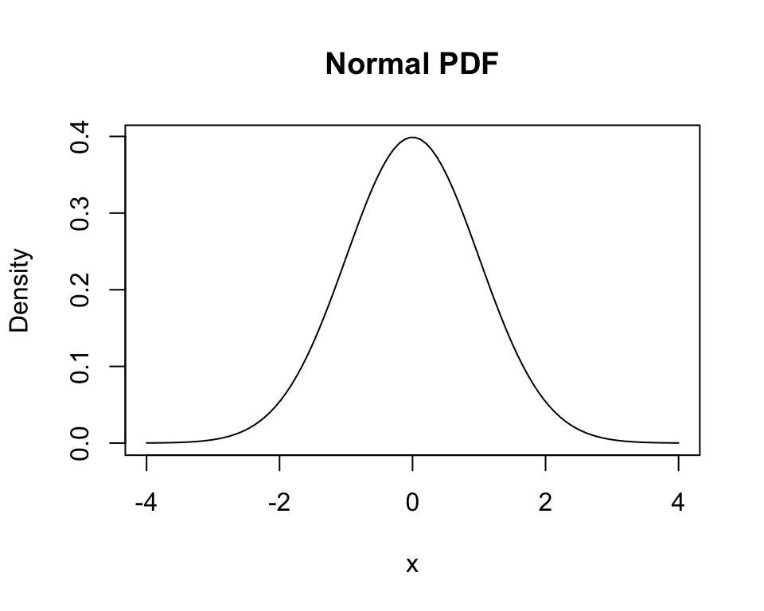

```r
x <- seq(-4, 4, length=100)

# PDF plot
plot(x, dnorm(x), type='l', main='Normal PDF', ylab='Density', xlab='x')
```

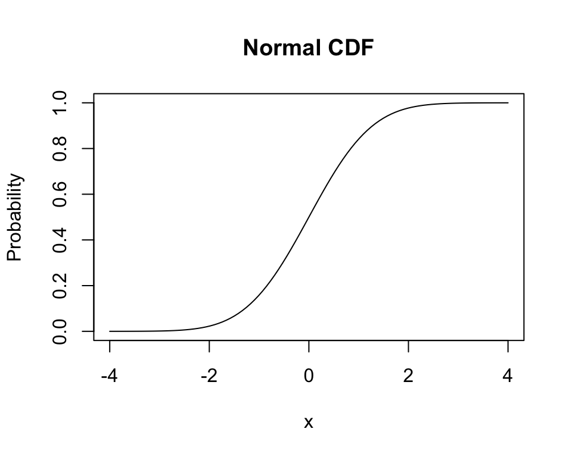

```r
# CDF plot
plot(x, pnorm(x), type='l', main='Normal CDF', ylab='Probability', xlab='x')
```

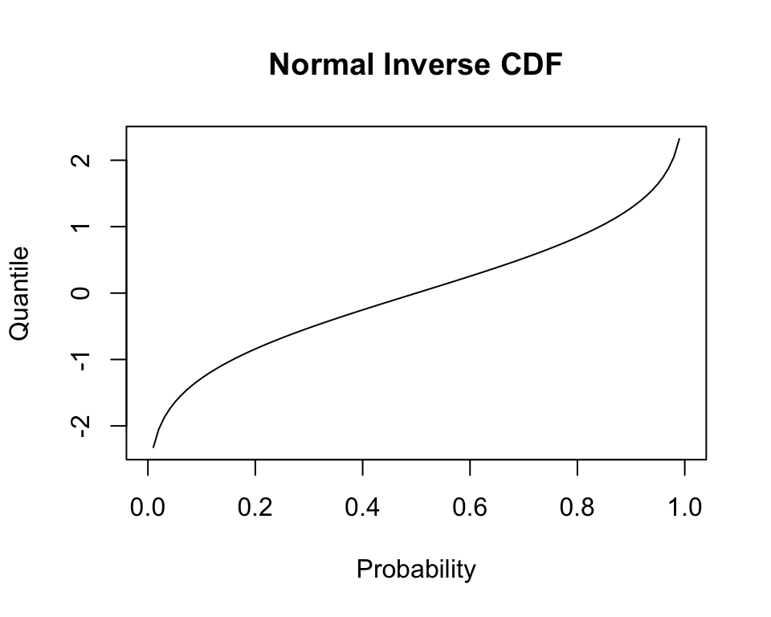

```r
# Inverse CDF plot
p <- seq(0, 1, length=100)
plot(p, qnorm(p), type='l', main='Normal Inverse CDF', ylab='Quantile', xlab='Probability')
```

3. For each of the following statements, think about them carefully and respond briefly to each.
   1. What is the support (i.e. set of possible outcomes with nonzero probability) of a normal RV?
   2. What does the empirical rule say?
   3. What are the EV and SD of a normal?
   4. How do you read a QQ plot, what do you look for?
   5. What does standard normal mean?
   6. What’s the formula for computing a Z-score of a point?
   7. When and how can you approximate a binomial with a normal?
   8. How do you tell which direction to ±0.5 when applying continuity correction?
   9. What’s the general form of the formula for a confidence intervaL?
   10. What exactly does “95% confidence” mean?